# Análisis Descriptivo información del portal de datos públicos de Medellín (MEData).

#### Tiempo de notificación vs

##### edad grupo

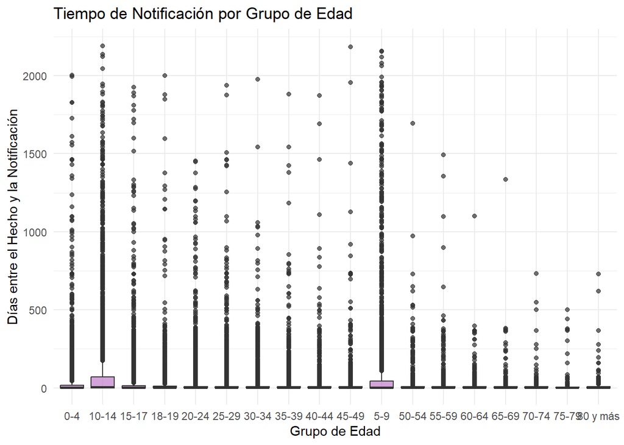

| grupo_edad | media | desviacion |
| --- | --- | --- |
| 5-9 | 100.23702 | 281.50189 |
| 10-14 | 90.78410 | 226.51790 |
| 0-4 | 49.39455 | 156.04100 |
| 15-17 | 46.03355 | 159.80380 |
| 18-19 | 36.32272 | 145.75081 |
| 20-24 | 22.15293 | 90.31745 |
| 45-49 | 20.21668 | 102.44217 |
| 25-29 | 20.19245 | 88.69424 |
| 35-39 | 17.84297 | 80.86948 |
| 30-34 | 17.82758 | 72.80912 |

[output cut: 8 more lines]

##### antecedentes

[figure not shown]

##### def_naturaleza

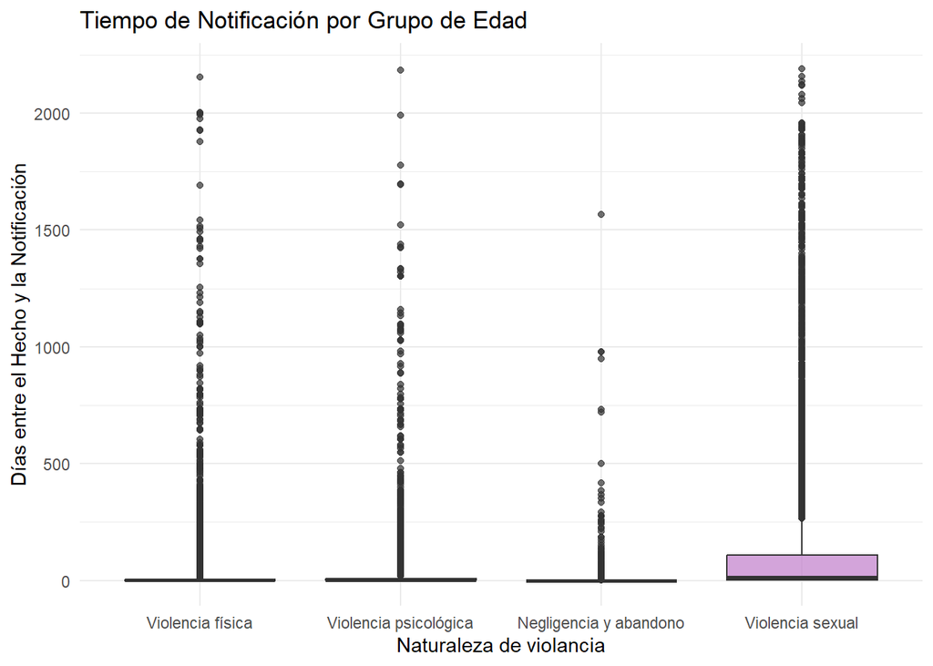

```
## # A tibble: 4 × 5
##   def_naturaleza          media    sd mediana   IQR
##   <fct>                   <dbl> <dbl>   <dbl> <dbl>
## 1 Violencia sexual       113.   252.       14   105
## 2 Violencia psicológica   20.6   98.9       2     7
## 3 Violencia física        14.7   77.6       1     5
## 4 Negligencia y abandono   4.43  45.9       0     0
```

El tiempo de notificación varía según el tipo de violencia. La violencia sexual tiene la mediana más alta (14 días) y mayor dispersión, lo que indica retrasos significativos en la denuncia. En contraste, la violencia psicológica y física se notifican con mayor rapidez (medianas de 2 y 1 día, respectivamente), mientras que la negligencia y abandono casi no presentan tiempos de espera. Estos datos reflejan posibles barreras en la denuncia de violencia sexual y la necesidad de estrategias para facilitarla.

##### área

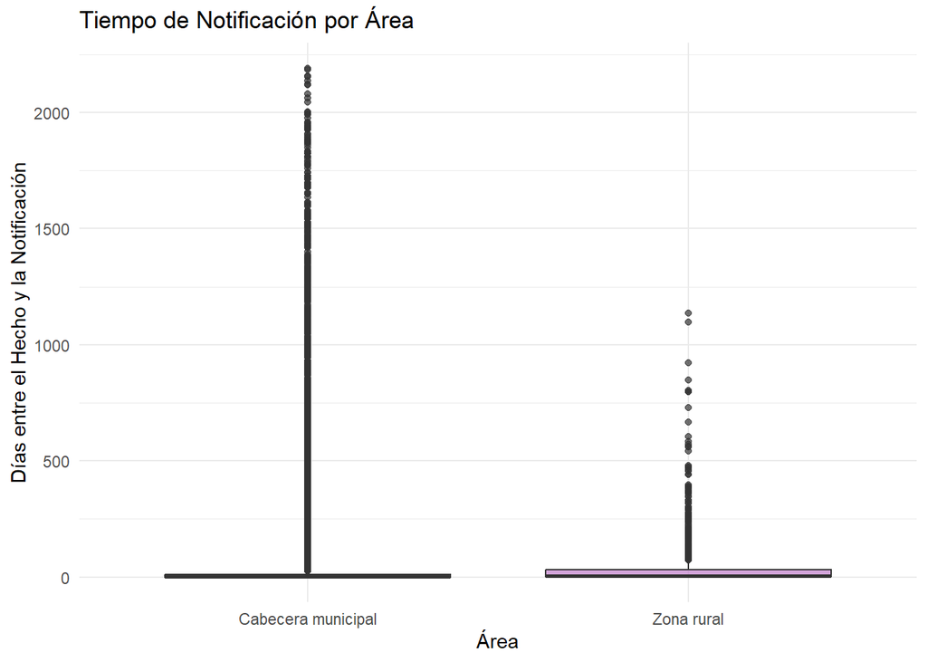

```
## # A tibble: 3 × 6
##   area_                  n media    sd mediana   IQR
##   <chr>              <int> <dbl> <dbl>   <dbl> <dbl>
## 1 Zona rural          1107  46.8  116.       4    29
## 2 Cabecera municipal 48396  39.4  151.       2    10
## 3 <NA>                   2   0      0        0     0
```

Esta gráfica y los datos sugieren que el tiempo de notificación es generalmente bajo en ambas áreas, pero con una mayor dispersión en cabeceras municipales. Aunque la mediana en zonas rurales es más alta (4 días vs. 2 días), la diferencia es pequeña. Sin embargo, el IQR más amplio en zonas rurales (29 vs. 10 días) indica que algunos casos tardan mucho más en ser denunciados.

#### Antecedentes

##### Reincidencia según la violencia

| def_naturaleza | antec | n | proporcion |
| --- | --- | --- | --- |
| Violencia física | No | 21635 | 89.5044 |
| Violencia física | Sí | 2537 | 10.4956 |
| Violencia psicológica | No | 8673 | 98.0332 |
| Violencia psicológica | Sí | 174 | 1.9668 |
| Negligencia y abandono | No | 4047 | 99.6798 |
| Negligencia y abandono | Sí | 13 | 0.3202 |
| Violencia sexual | No | 11623 | 93.5377 |
| Violencia sexual | Sí | 803 | 6.4623 |

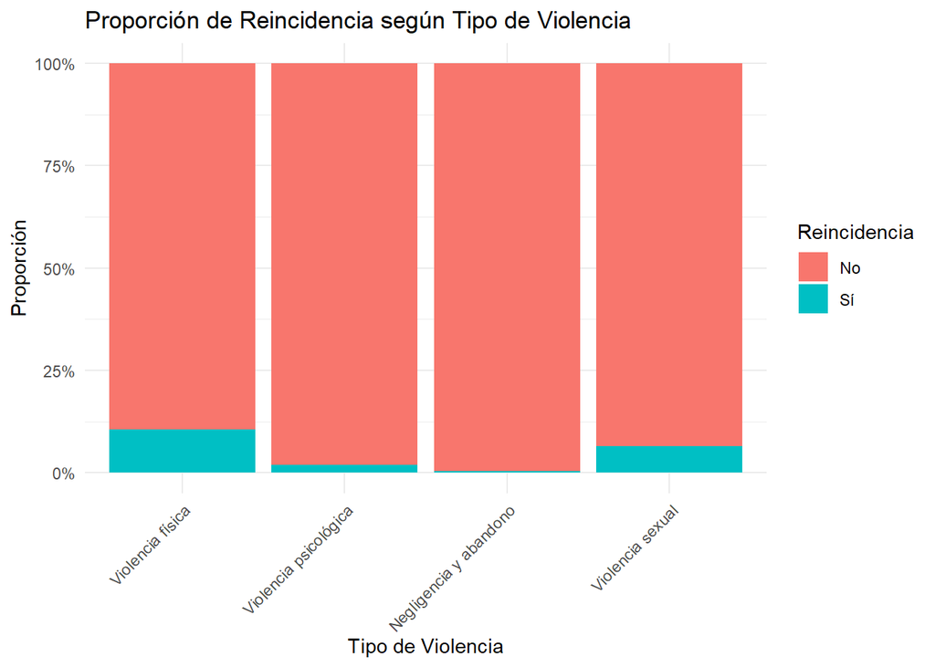

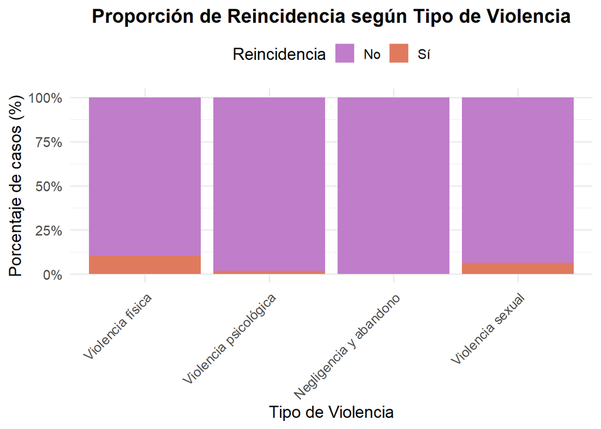

##### Reincidencia según área

La reincidencia es más alta en las zonas rurales (15.14%) que en las cabeceras municipales (6.94%). Esto sugiere que en las zonas rurales hay más casos de revictimización, posiblemente por falta de acceso a medidas de protección o por dinámicas familiares y comunitarias donde la violencia es más recurrente. En contraste, en las cabeceras municipales la reincidencia es menor, lo que podría indicar una mayor presencia de instituciones de apoyo o mecanismos de protección más efectivos.

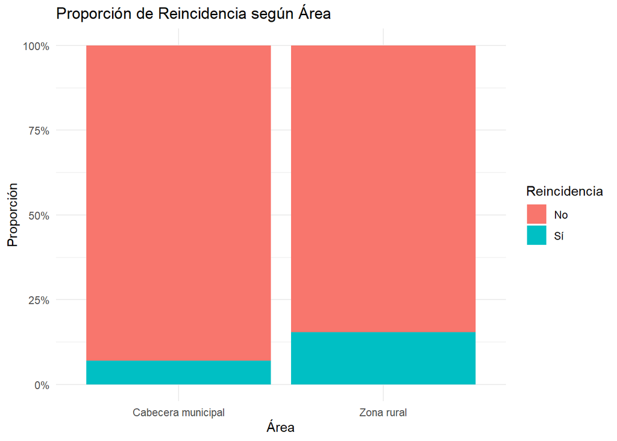

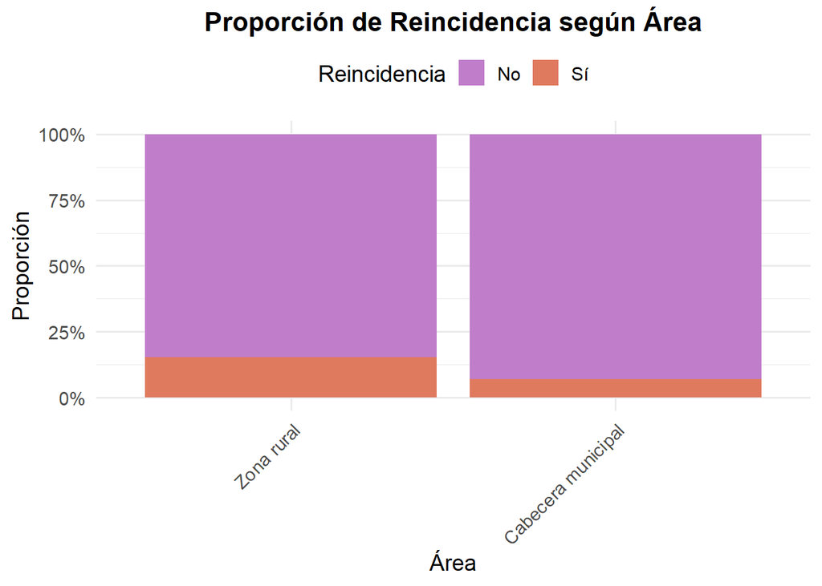

#### Convivencia

##### tipo violencia

| def_naturaleza | conv_agre | n | proporcion |
| --- | --- | --- | --- |
| Violencia física | No | 13400 | 55.44 |
| Violencia física | Sí | 10772 | 44.56 |
| Violencia psicológica | No | 5657 | 63.95 |
| Violencia psicológica | Sí | 3189 | 36.05 |
| Negligencia y abandono | No | 1318 | 32.46 |
| Negligencia y abandono | Sí | 2742 | 67.54 |
| Violencia sexual | No | 10469 | 84.26 |
| Violencia sexual | Sí | 1956 | 15.74 |

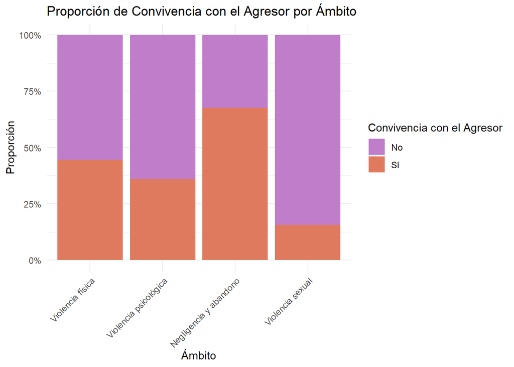

##### Relación entre el parentesco y la convivencia

| parentezco_agresor | conv_agre | n | proporcion |
| --- | --- | --- | --- |
| Amigo(a) | No | 1356 | 94.56 |
| Amigo(a) | Sí | 78 | 5.44 |
| Compañero(a) de estudio | No | 252 | 96.18 |
| Compañero(a) de estudio | Sí | 10 | 3.82 |
| Compañero(a) de trabajo | No | 160 | 96.97 |
| Compañero(a) de trabajo | Sí | 5 | 3.03 |
| Conocido(a) | No | 1950 | 74.48 |
| Conocido(a) | Sí | 668 | 25.52 |
| Desconocido(a) | No | 3438 | 99.28 |
| Desconocido(a) | Sí | 25 | 0.72 |

[output cut: 24 more lines]

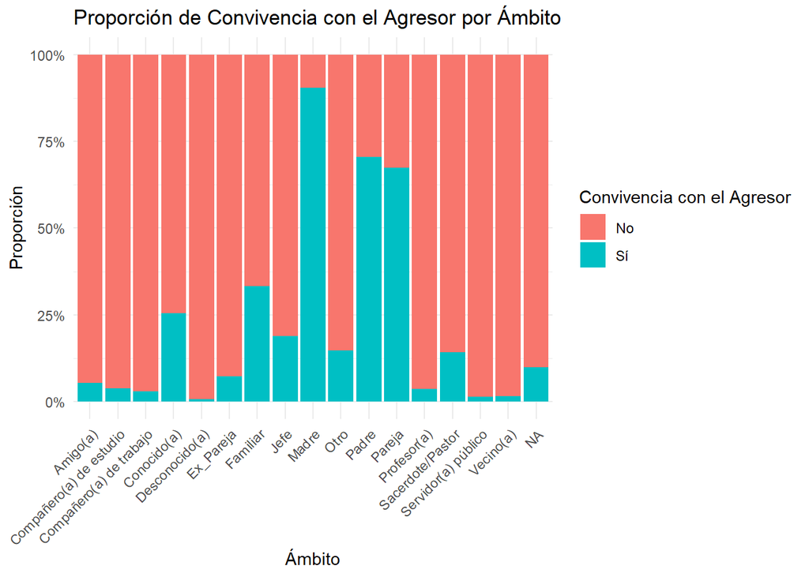